# ECo 602 - Analysis of Environmental Data

## `read.csv()`

Used to load data from a .csv file into a data frame.Needs either an exact file path, the relative file path if the .csv is stored in the working directory, or can be used with the `here()` function.

```r
#load the "here()" function
require(here)


#this locates the "bird.sta.csv" file that is located in my "data" folder within my R project and assigns it to a new object called "dat_bird"
dat_bird = read.csv(here("data", "bird.sta.csv"))

#head() returns only the first few rows of the object.
head(dat_bird)
```

```
##   basin sub sta AMCR AMDI AMGO AMRO BCCH BEWR BGWA BHCO BHGR BRCR BTPI BUSH
## 1     D  AL   1    0    0    0    1    0    0    0    0    2    0    0    0
## 2     D  AL   2    0    0    0    0    0    0    0    0    2    0    0    0
## 3     D  AL   3    0    0    0    0    0    1    0    0    0    0    0    0
## 4     D  AL   4    0    0    0    0    0    0    0    0    0    0    0    0
## 5     D  AL   5    0    0    0    0    0    0    0    0    0    0    0    0
## 6     D  AL   6    0    0    0    0    0    0    0    0    1    1    0    0
##   CBCH CEWA CORA COYE DEJU DOWO EUST EVGR GCKI GCSP GRJA HAFL HAWO HETH HEWA
## 1    2    0    0    0    0    0    0    0    0    0    0    0    0    0    0
## 2    2    0    0    0    0    0    0    0    0    0    0    0    2    0    0
## 3    0    0    0    0    0    0    0    0    0    0    0    0    1    0    0
## 4    1    0    0    0    0    0    0    0    0    0    0    0    0    0    0
## 5    1    0    0    0    0    0    0    0    1    0    0    0    0    0    0
## 6    0    0    0    0    0    0    0    0    0    0    0    0    0    0    0
##   HOME HOWR HUVI MALL MAMU MGWA MOQU NOFL OCWA OSFL PISI PIWO PSFL PUFI PYOW
```

[output cut: 27 more lines]

# Part 2: Data Anaylsis

This section will be a complete data analysis of the delomys data set.

# Data Exploration

## Numerical Exploration

The `shapiro.test()` provides a numeric test of normality with the null hypothesis being that the data is normally distributed. If the returned p-value is less than 0.05, then there is evidence that you can reject the null.

```r
#read in the data
require(here)
dat_del = read.csv(here("data", "delomys.csv"))


#get stats for the body mass column...
summary(dat_del$body_mass)
```

```
##    Min. 1st Qu.  Median    Mean 3rd Qu.    Max.
##    5.00   35.00   43.00   44.06   54.00  105.00
```

```r
#...and for the body length
summary(dat_del$body_length)
```

```
##    Min. 1st Qu.  Median    Mean 3rd Qu.    Max.
##    49.0   106.0   116.0   114.7   124.0   265.0
```

```r
#test for normality in the body mass data
shapiro.test(dat_del$body_mass)
```

```
##
##  Shapiro-Wilk normality test
##
## data:  dat_del$body_mass
## W = 0.99506, p-value = 4.33e-05
```

```r
#test for normality in the body length data
shapiro.test(dat_del$body_length)
```

```
##
##  Shapiro-Wilk normality test
##
## data:  dat_del$body_length
## W = 0.87609, p-value < 2.2e-16
```

## Graphical Exploration

### scatterplot of body mass and body length

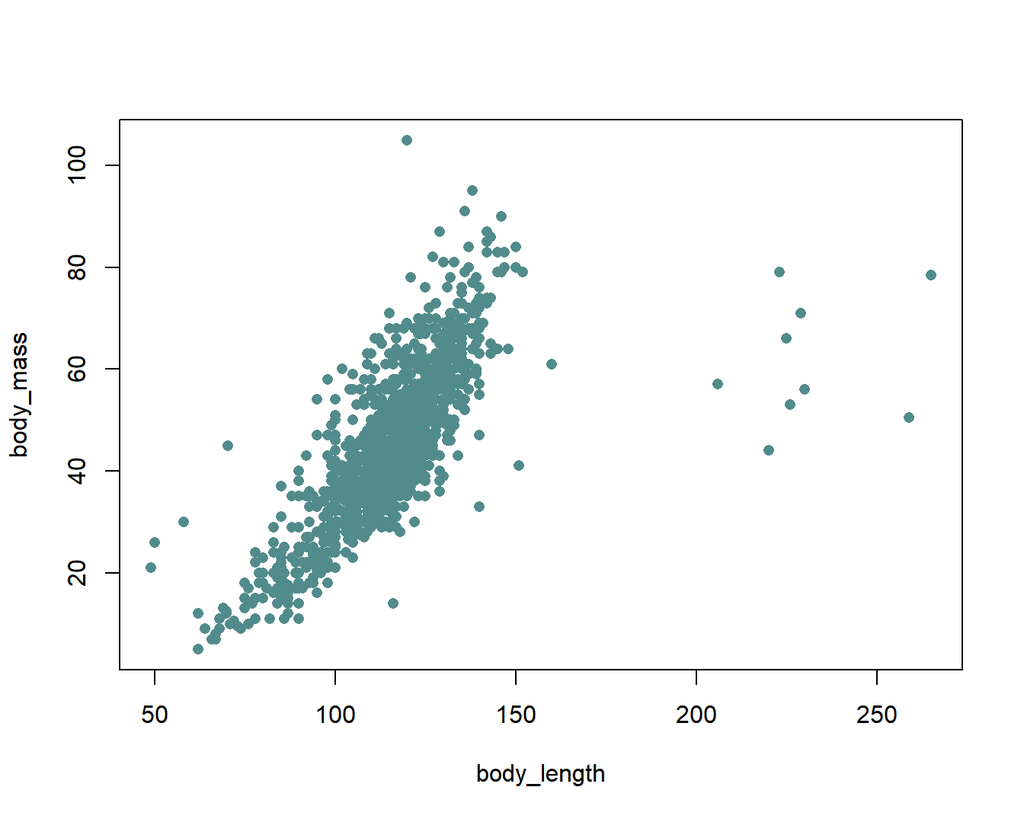

```r
plot(body_mass ~ body_length, data = dat_del,
     col = "darkslategray4",
     pch = 16)
```

### histogram of body mass

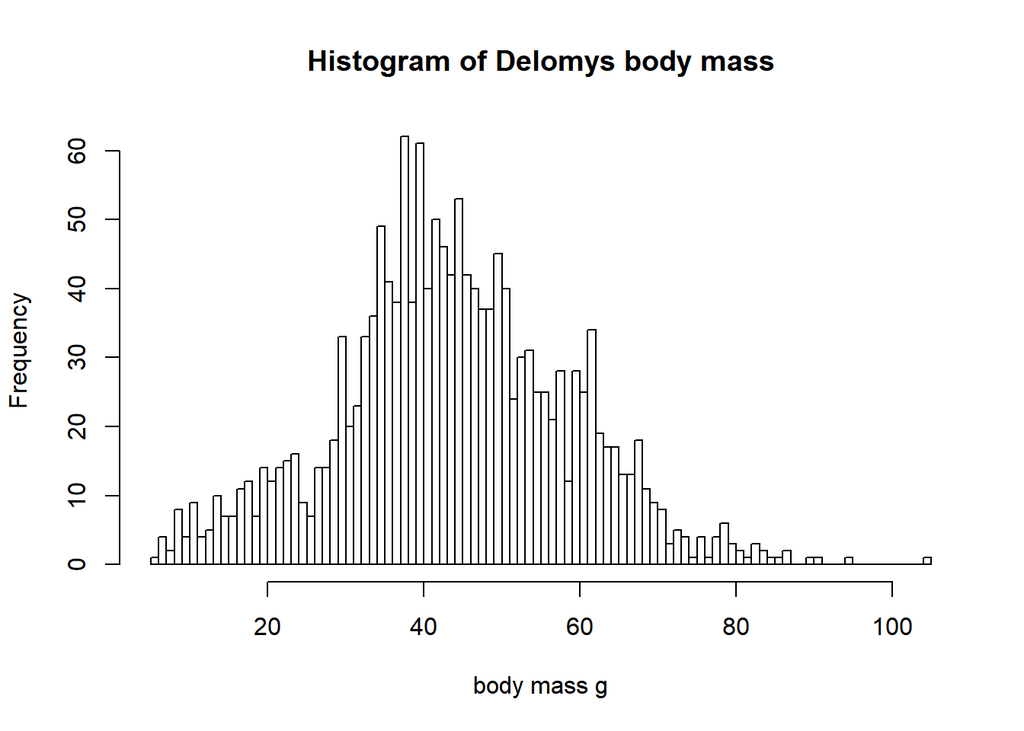

```r
hist(dat_del$body_mass,
     breaks = 80, # narrows the bars of the histogram so that there is less binning of values
     main = "Histogram of Delomys body mass",
     xlab = "body mass g")
```

### histogram of body length

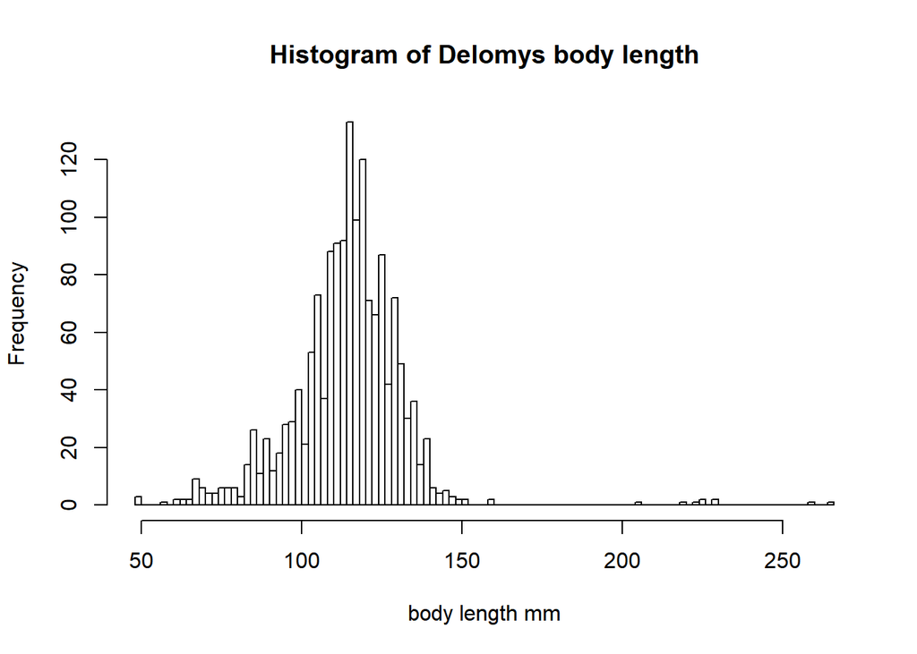

```r
hist(dat_del$body_length,
     breaks = 80, # narrows the bars of the histogram so that there is less binning of values
     main = "Histogram of Delomys body length",
     xlab = "body length mm")
```

### boxplot of body mass, conditioned on species

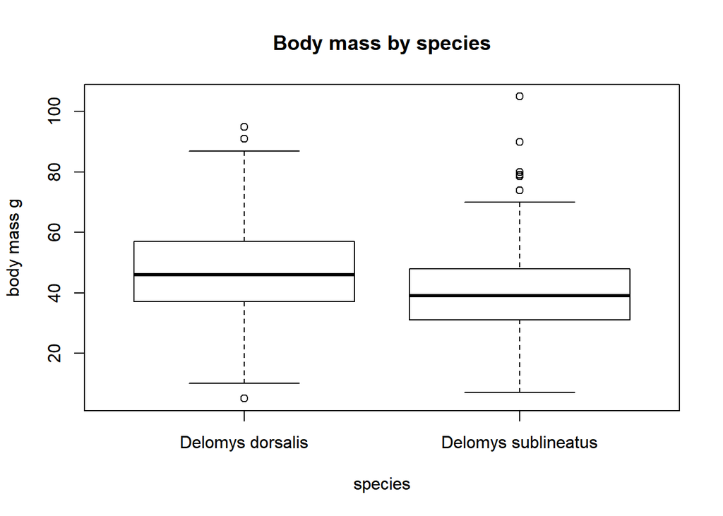

```r
boxplot(body_mass ~ binomial, data = dat_del,
        main = "Body mass by species",
        xlab = "species",
        ylab = "body mass g")
```

### boxplot of body mass, conditioned on sex

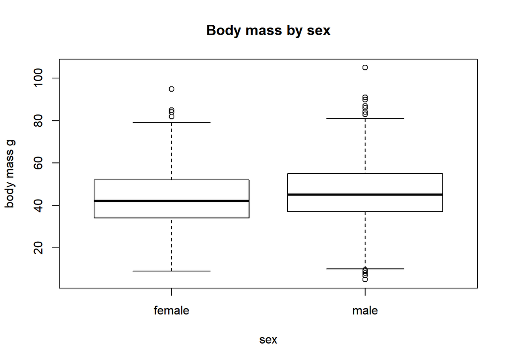

```r
boxplot(body_mass ~ sex, data = dat_del,
        main = "Body mass by sex",
        ylab = "body mass g")
```

### boxplot of body mass, conditioned on both species and sex

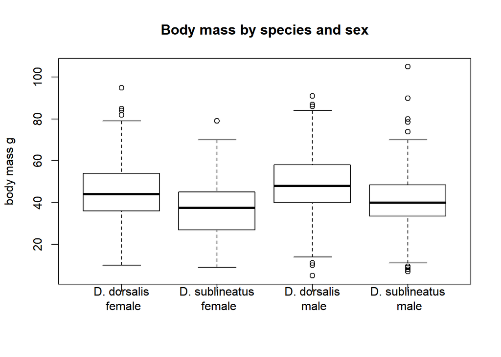

```r
boxplot(body_mass ~ binomial + sex, data = dat_del,
        main = "Body mass by species and sex",
        xlab = " ",
        ylab = "body mass g",
        names = list("D. dorsalis\n female",
                     "D. sublineatus\n female",
                     "D. dorsalis\n male",
                     "D. sublineatus\n male"))  #the \n inserts a line break so that the name is continued below. In this case it is needed to make the name shorter so that they are all displayed.
```

## Delomys Data Exploration Questions

### 1

Qualitatively describe the relationship between body mass and length.

- Does the relationship seem linear, curved, nonexistent?

*Overall there is a fairly strong linear relationship between body mass and body length. This relationship breaks down at the ends a bit, with individuals that are shorter than ~55mm and longer than ~150mm not folowing the same linear slope. I feel like this isn’t uncommon to see with the fringe data in a dataset however.*

### 2

Qualitatively describe the shapes of the histograms.

- Do the data appear normally-distributed? Explain why or why not.

*Both the body mass and body length histograms show data that appears to be mostly normally distributed. The body length data do have some outlying data points that are beyond the expected spread or normal data, but overall both data sets have a strong peak in the middle and a mostly evenly tapered spread outward from the mean. The trailing tail of outliying values in the body length data is a bit worrysome, but I’d say that the data can still be treated as normal due to the fact that it is just a small fraction of points that don’t conform.*

### 3

Using both the histograms and normality tests, do you think the (unconditioned) body masses and body length are normally-distributed?

- Contrast your visual assessment of normality to the results of the numerical normality tests.

*The results from the `shapiro.test()` seem to say that my visual interpretation of the data being normally distributed was quite wrong. The p-values for both the body mass and body length data were much less than 0.05 that allows the rejection of normality. I’m honestly surprised that data that appears this normal can have such a low p-value.*

### 4

Examine the conditional boxplots. Describe any graphical evidence you see for body mass differences based on species and/or sex.

*The boxplot of body mass by species shows that D. dorsalis are a few grams heavier, on average, than D. sublineatus.The boxplot of body mass by sex shows that males are a few grams heavier, on average, than females. The boxplot of body mass by species and sex shows that the relationship is similar across species and sex.*

# Model Building

```r
#Model 1: simple linear regression
fit1 = lm(body_length ~ body_mass, data = dat_del)

#Model 2: 1-way ANOVA
fit2 = lm(body_mass ~ sex, data = dat_del)

#Model 3: 1-way ANOVA
fit3 = lm(body_mass ~ binomial, data = dat_del)

#Model 4: 2-way additive ANOVA
fit4 = lm(body_mass ~ sex + binomial, data = dat_del)

#Model 5: 2-way factorial ANOVA
fit5 = lm(body_mass ~ sex * binomial, data = dat_del)
```

# Model Diagnostics

### Graphical Normality of Residuals Check

You can use the `residuals()` function to calculate the residuals of a model, and the `hist()` function to plot them to check for normality.

- The `breaks =` argument was used to reduce the binning of values.

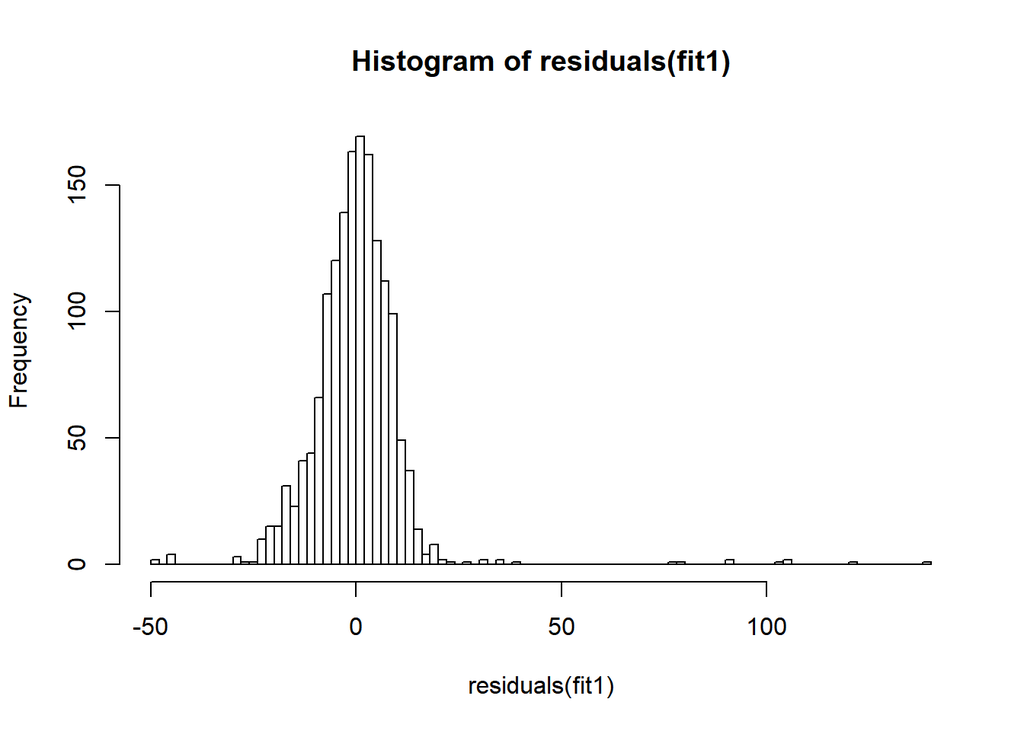

```r
hist(residuals(fit1), breaks = 80)
```

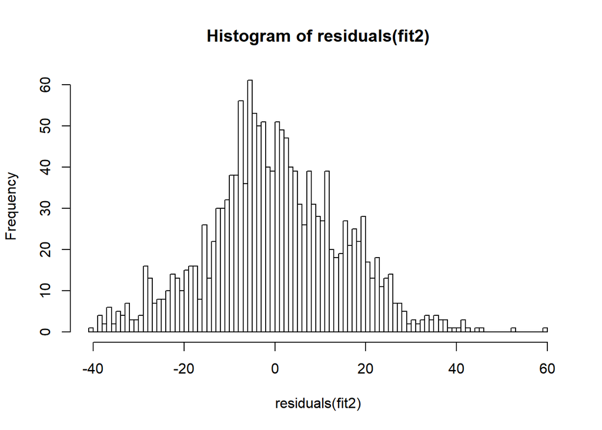

```r
hist(residuals(fit2), breaks = 80)
```

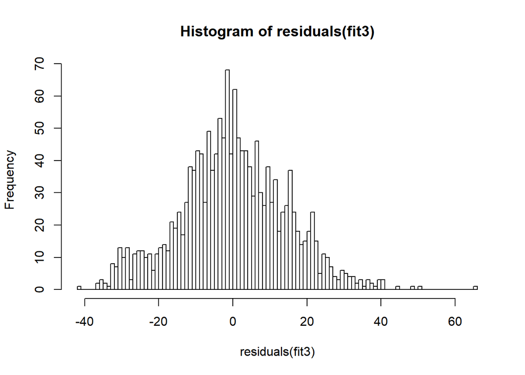

```r
hist(residuals(fit3), breaks = 80)
```

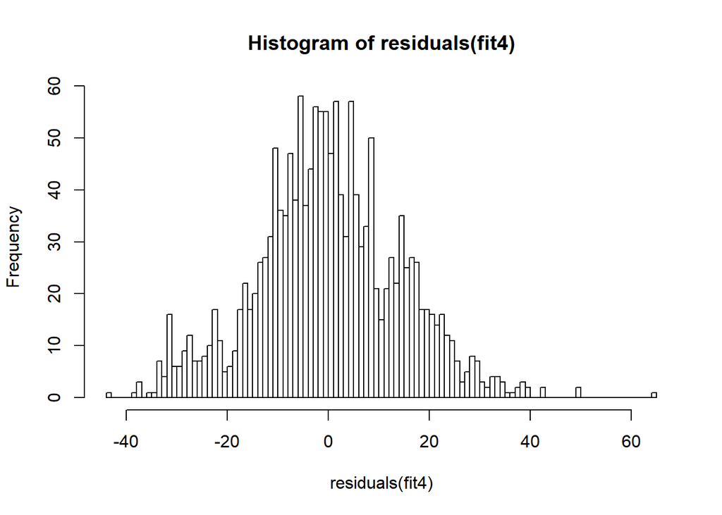

```r
hist(residuals(fit4), breaks = 80)
```

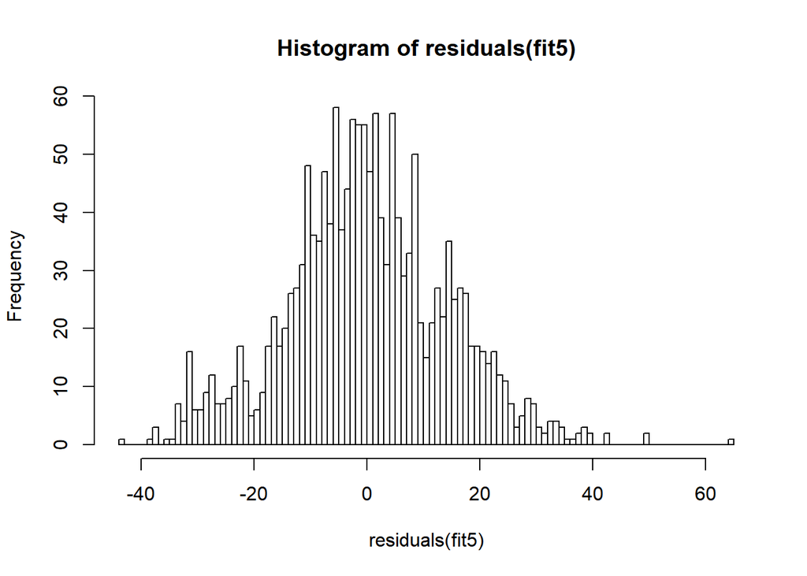

```r
hist(residuals(fit5), breaks = 80)
```

### Numerical Normality of Residuals Check

The `shapiro.test()` can be used to check the normality of the model residuals as well.

```r
shapiro.test(residuals(fit1))
```

```
##
##  Shapiro-Wilk normality test
##
## data:  residuals(fit1)
## W = 0.73462, p-value < 2.2e-16
```

```r
shapiro.test(residuals(fit2))
```

```
##
##  Shapiro-Wilk normality test
##
## data:  residuals(fit2)
## W = 0.99563, p-value = 0.0001541
```

```r
shapiro.test(residuals(fit3))
```

```
##
##  Shapiro-Wilk normality test
##
## data:  residuals(fit3)
## W = 0.99535, p-value = 8.103e-05
```

```r
shapiro.test(residuals(fit4))
```

```
##
##  Shapiro-Wilk normality test
##
## data:  residuals(fit4)
## W = 0.99525, p-value = 6.805e-05
```

```r
shapiro.test(residuals(fit5))
```

```
##
##  Shapiro-Wilk normality test
##
## data:  residuals(fit5)
## W = 0.99526, p-value = 6.816e-05
```

## Model Diagnostics Questions

### 1

What do you conclude about residual normality based on the numerical and graphical diagnostics?

*I conclude that data can look very normal while still testing as non-normal. I guess I would have a hard time arguing against p-values that are this low and trying to say that these residuals are normally distributed. If I was trying to publish research and came across this situation, I feel like I’d have to treat it as non-normal. That said, I think I remember that the functions and models that assume normality are fairly forgiving, and so I would probably run these data as if they were normal as well, just to see how the results differed.*

### 2

Are violations of the normality assumption equally severe for all of the models?

*No. The shapiro test results in a p-value of less than 0.05 for all of the models, but fit1 has an extremely low p-value, while fit2 is quite a bit higher despite still being well lower than 0.05. Fit3, fit4, and fit5 are all in the middle and extremely similar.*

# Model Interpretation

## Body Length

```r
#this makes a nicer summary output and rounds the decimal
knitr::kable(coef(summary(fit1)), digits = 4)
```

|  | Estimate | Std. Error | t value | Pr(>\|t\|) |
| --- | --- | --- | --- | --- |
| (Intercept) | 76.1247 | 0.9158 | 83.1226 | 0 |
| body_mass | 0.8755 | 0.0197 | 44.4630 | 0 |

### Questions

- What is the magnitude of the mass/length relationship?
  - *0.875 g/mm*
- What is the expected body length of an an animal that weighs 100g?
  - *163.6 mm*
- What is the expected body length of an animal that weighs 0g?
  - *76.125 mm*

## Body Mass: Model Coefficients

```r
#base level for sex
knitr::kable(coef(summary(fit2)), digits = 4)
```

|  | Estimate | Std. Error | t value | Pr(>\|t\|) |
| --- | --- | --- | --- | --- |
| (Intercept) | 42.7115 | 0.5289 | 80.7564 | 0e+00 |
| sexmale | 2.7841 | 0.7456 | 3.7340 | 2e-04 |

```r
#base level for species
knitr::kable(coef(summary(fit3)), digits = 4)
```

|  | Estimate | Std. Error | t value | Pr(>\|t\|) |
| --- | --- | --- | --- | --- |
| (Intercept) | 46.7524 | 0.4500 | 103.8958 | 0 |
| binomialDelomys sublineatus | -7.6831 | 0.7605 | -10.1032 | 0 |

## Body Mass: ANOVA

```r
knitr::kable(anova(fit2), digits = 4)
```

|  | Df | Sum Sq | Mean Sq | F value | Pr(>F) |
| --- | --- | --- | --- | --- | --- |
| sex | 1 | 3061.678 | 3061.6779 | 13.9429 | 2e-04 |
| Residuals | 1578 | 346507.131 | 219.5863 | NA | NA |

```r
knitr::kable(anova(fit3), digits = 4)
```

|  | Df | Sum Sq | Mean Sq | F value | Pr(>F) |
| --- | --- | --- | --- | --- | --- |
| binomial | 1 | 21289.68 | 21289.6805 | 102.0751 | 0 |
| Residuals | 1583 | 330164.45 | 208.5688 | NA | NA |

```r
knitr::kable(anova(fit4), digits = 4)
```

|  | Df | Sum Sq | Mean Sq | F value | Pr(>F) |
| --- | --- | --- | --- | --- | --- |
| sex | 1 | 3061.678 | 3061.6779 | 14.9584 | 1e-04 |
| binomial | 1 | 23727.134 | 23727.1342 | 115.9232 | 0e+00 |
| Residuals | 1577 | 322779.997 | 204.6798 | NA | NA |

```r
knitr::kable(anova(fit5), digits = 4)
```

|  | Df | Sum Sq | Mean Sq | F value | Pr(>F) |
| --- | --- | --- | --- | --- | --- |
| sex | 1 | 3061.6779 | 3061.6779 | 14.9489 | 0.0001 |
| binomial | 1 | 23727.1342 | 23727.1342 | 115.8500 | 0.0000 |
| sex:binomial | 1 | 0.7914 | 0.7914 | 0.0039 | 0.9504 |
| Residuals | 1576 | 322779.2058 | 204.8091 | NA | NA |

### Questions

- Are sex and species significant predictors for body mass?
  - *Yes, both sex and species are significant predictors for body mass since they both have p-values of less than 0.05 and high mean square values.*
- Is there a significant interaction?
  - *No, there is not a significant interaction since the p-value is very high and the mean squares is very low.*
- Does the significance (as measured by p-value) of either of the main effects (sex and species) differ much between the single-predictor models, the additive model, and the interactive model?
  - *No, not really. There is a slight change (0.0001 higher) in the p-value for sex in the single predictor model, but that’s it.*

# Model Comparison: Body Mass

You built four different models of body mass. How do you choose the best one?

One option is to choose the model with the lowest AIC. You can calculate AIC using the appropriately named AIC() function.

```r
AIC(fit1, fit2, fit3, fit4, fit5)
```

```
##      df      AIC
## fit1  3 12291.67
## fit2  3 13006.80
## fit3  3 12966.36
## fit4  4 12896.73
## fit5  5 12898.72
```